# Rohith_Kumar_Thakur_26-12-2022

### Part 5 Visualization

```python
import seaborn as sns
from matplotlib import pyplot as plt
```

```python
df
```

|  | Year | Month | Laptop/Desktop | Type_of_Customers? | Coming from | Place_in_India | Level 1 | Level 2 | Level 3 | Level 4 | inc/dec percentage | Level2/Level1 | sum_of_level4 | rank | sum_level4/sum_level1 | sum_level3/sum_level1 | sum_level2/sum_level1 | level4/level1 |
| --- | --- | --- | --- | --- | --- | --- | --- | --- | --- | --- | --- | --- | --- | --- | --- | --- | --- | --- |
| 1764 | 2022 | June | Desktop_Website | New_Customer | Direct_traffic | Pune | 9083552.00 | 4079301.00 | 1942557 | 923720 | 89.83 | 0.449087 | 127917989 | 1.0 | 0.07555 | 0.192726 | 0.456983 | 0.101691 |
| 263 | 2020 | May | Desktop_Website | New_Customer | Direct_traffic | Indore | 2739053.00 | 2141881.00 | 1649732 | 1251258 | 54.32 | 0.781979 | 127917989 | 1.0 | 0.07555 | 0.192726 | 0.456983 | 0.456821 |
| 1284 | 2021 | October | Desktop_Website | New_Customer | Direct_traffic | Pune | 8188402.00 | 3435272.00 | 862600 | 558073 | 93.18 | 0.419529 | 127917989 | 1.0 | 0.07555 | 0.192726 | 0.456983 | 0.068154 |
| 983 | 2021 | May | Desktop_Website | New_Customer | Direct_traffic | Indore | 2341270.00 | 892572.00 | 557801 | 447909 | 80.87 | 0.381234 | 127917989 | 2.0 | 0.07555 | 0.192726 | 0.456983 | 0.191310 |
| 262 | 2020 | May | Desktop_Website | New_Customer | Direct_traffic | Dehradun | 1412563.00 | 1121317.00 | 994925 | 873534 | 38.16 | 0.793817 | 127917989 | 2.0 | 0.07555 | 0.192726 | 0.456983 | 0.618404 |
| ... | ... | ... | ... | ... | ... | ... | ... | ... | ... | ... | ... | ... | ... | ... | ... | ... | ... | ... |
| 1480 | 2022 | January | Laptop_Website | Existing_Customer | Unidentified_Sources | Bengaluru | 783870.22 | 358215.42 | 6711 | 1040 | 99.87 | 0.456983 | 127917989 | 719.0 | 0.07555 | 0.192726 | 0.456983 | 0.001327 |
| 1420 | 2021 | December | Laptop_Website | Existing_Customer | Unidentified_Sources | Bengaluru | 783870.22 | 358215.42 | 7222 | 1102 | 99.86 | 0.456983 | 127917989 | 719.0 | 0.07555 | 0.192726 | 0.456983 | 0.001406 |
| 101 | 2020 | February | Laptop_Website | Existing_Customer | Unidentified_Sources | Hyderabad | 783870.22 | 358215.42 | 7964 | 1697 | 99.78 | 0.456983 | 127917989 | 720.0 | 0.07555 | 0.192726 | 0.456983 | 0.002165 |
| 1422 | 2021 | December | Laptop_Website | Existing_Customer | Unidentified_Sources | Dehradun | 783870.22 | 358215.42 | 10240 | 860 | 99.89 | 0.456983 | 127917989 | 720.0 | 0.07555 | 0.192726 | 0.456983 | 0.001097 |
| 1482 | 2022 | January | Laptop_Website | Existing_Customer | Unidentified_Sources | Dehradun | 783870.22 | 358215.42 | 8901 | 766 | 99.90 | 0.456983 | 127917989 | 720.0 | 0.07555 | 0.192726 | 0.456983 | 0.000977 |

2160 rows × 18 columns

#### 1.A line graph for “Level 2” for the different “Place_in_India?” over the months of the year 2020 & 2021.

```python
df7 = df.copy()
```

```python
df7['yearmonth'] = df7['Year'].astype('string').str.cat(df7['Month'], sep ="_")
df7['month1'] = df7['Month']
df7.replace({'month1': {'January': 1,'February': 2, 'March': 3, 'April': 4,'June': 6, 'May': 5,
    'July': 7,'August': 8, 'September': 9,'October': 10,'November': 11, 'December': 12}}, inplace = True)
df8 = df7.loc[(df7['Year'] == 2020)| (df7['Year'] == 2021)].sort_values(by = 'Year', ascending = True)
df8 = df8.sort_values(by = ['Year','month1'])
df8
```

|  | Year | Month | Laptop/Desktop | Type_of_Customers? | Coming from | Place_in_India | Level 1 | Level 2 | Level 3 | Level 4 | inc/dec percentage | Level2/Level1 | sum_of_level4 | rank | sum_level4/sum_level1 | sum_level3/sum_level1 | sum_level2/sum_level1 | level4/level1 | yearmonth | month1 |
| --- | --- | --- | --- | --- | --- | --- | --- | --- | --- | --- | --- | --- | --- | --- | --- | --- | --- | --- | --- | --- |
| 1 | 2020 | January | Desktop_Website | Existing_Customer | From LinkedIn | Hyderabad | 783870.22 | 358215.42 | 41460 | 11916 | 98.48 | 0.456983 | 127917989 | 567.0 | 0.07555 | 0.192726 | 0.456983 | 0.015201 | 2020_January | 1 |
| 22 | 2020 | January | Desktop_Website | New_Customer | Direct_traffic | Dehradun | 401292.00 | 171322.00 | 51069 | 36016 | 91.02 | 0.426926 | 127917989 | 289.0 | 0.07555 | 0.192726 | 0.456983 | 0.089750 | 2020_January | 1 |
| 21 | 2020 | January | Desktop_Website | New_Customer | Direct_traffic | Hyderabad | 292128.00 | 131890.00 | 50720 | 32140 | 89.00 | 0.451480 | 127917989 | 328.0 | 0.07555 | 0.192726 | 0.456983 | 0.110020 | 2020_January | 1 |
| 30 | 2020 | January | Laptop_Website | Existing_Customer | From LinkedIn | Bengaluru | 783870.22 | 358215.42 | 57469 | 13257 | 98.31 | 0.456983 | 127917989 | 551.0 | 0.07555 | 0.192726 | 0.456983 | 0.016912 | 2020_January | 1 |
| 32 | 2020 | January | Laptop_Website | Existing_Customer | From LinkedIn | Dehradun | 783870.22 | 358215.42 | 40947 | 13345 | 98.30 | 0.456983 | 127917989 | 550.0 | 0.07555 | 0.192726 | 0.456983 | 0.017025 | 2020_January | 1 |
| ... | ... | ... | ... | ... | ... | ... | ... | ... | ... | ... | ... | ... | ... | ... | ... | ... | ... | ... | ... | ... |
| 1383 | 2021 | December | Desktop_Website | Existing_Customer | From LinkedIn | Indore | 783870.22 | 358215.42 | 121227 | 45917 | 94.14 | 0.456983 | 127917989 | 254.0 | 0.07555 | 0.192726 | 0.456983 | 0.058577 | 2021_December | 12 |
| 1397 | 2021 | December | Desktop_Website | New_Customer | From LinkedIn | Dehradun | 141409.00 | 86114.00 | 43654 | 30962 | 78.10 | 0.608971 | 127917989 | 344.0 | 0.07555 | 0.192726 | 0.456983 | 0.218954 | 2021_December | 12 |
| 1438 | 2021 | December | Laptop_Website | New_Customer | Unidentified_Sources | Indore | 466715.00 | 207872.00 | 107705 | 30563 | 93.45 | 0.445394 | 127917989 | 346.0 | 0.07555 | 0.192726 | 0.456983 | 0.065485 | 2021_December | 12 |
| 1387 | 2021 | December | Desktop_Website | Existing_Customer | Direct_traffic | Dehradun | 783870.22 | 358215.42 | 109722 | 33111 | 95.78 | 0.456983 | 127917989 | 328.0 | 0.07555 | 0.192726 | 0.456983 | 0.042240 | 2021_December | 12 |
| 1422 | 2021 | December | Laptop_Website | Existing_Customer | Unidentified_Sources | Dehradun | 783870.22 | 358215.42 | 10240 | 860 | 99.89 | 0.456983 | 127917989 | 720.0 | 0.07555 | 0.192726 | 0.456983 | 0.001097 | 2021_December | 12 |

1440 rows × 20 columns

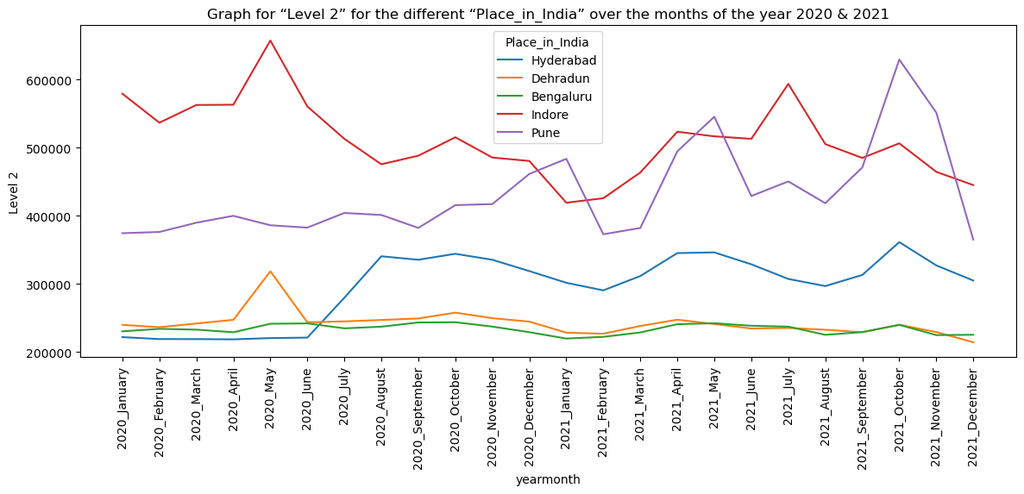

```python
plt.figure(figsize = (14,5))
sns.lineplot(data = df8, x = 'yearmonth', y = 'Level 2', hue = 'Place_in_India', ci = None).set(title =
                    'Graph for “Level 2” for the different “Place_in_India” over the months of the year 2020 & 2021')
plt.xticks(rotation = 90)
plt.show()
```

#### 2 A line graph for “Level 1” for the different “Laptop/Desktop” over the months of the year 2020 & 2021.

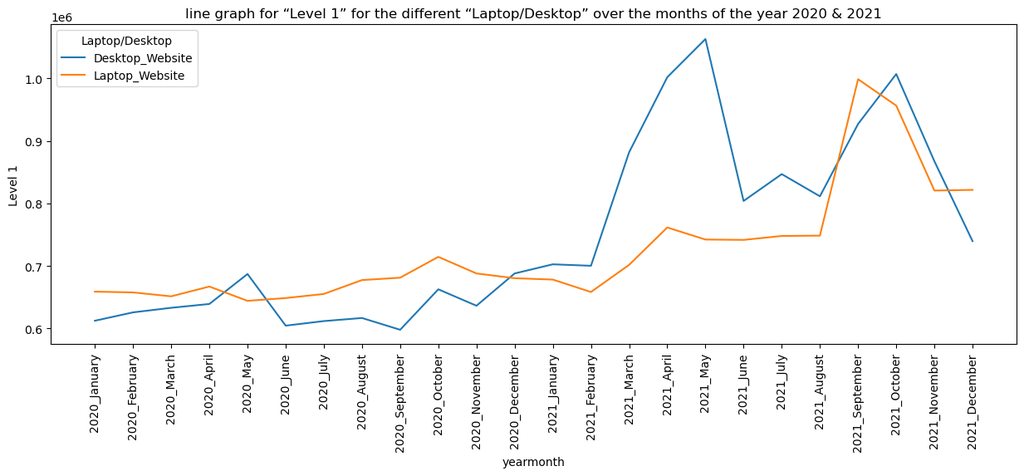

```python
plt.figure(figsize = (15,5))
sns.lineplot(data = df8, x = 'yearmonth', y = 'Level 1', hue = 'Laptop/Desktop', ci = None).set(title =
                    'line graph for “Level 1” for the different “Laptop/Desktop” over the months of the year 2020 & 2021')
plt.xticks(rotation = 90)
plt.show()
```

#### 3 A line graph for “Level 2” for the different “Coming from” over the months of the year 2021 & 2022

```python
df9 = df7.copy()
df9['Year'].unique()
```

```
array([2022, 2020, 2021], dtype=int64)
```

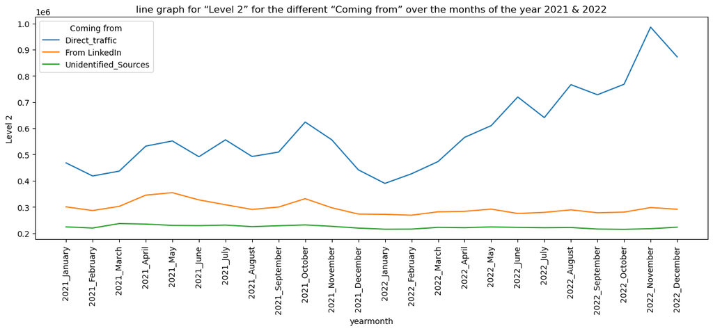

```python
plt.figure(figsize = (15,5))
sns.lineplot(data = df9.loc[(df['Year'] == 2021)|(df['Year'] == 2022)].sort_values(by = ['Year','month1'],
                        ascending = True), x = 'yearmonth', y = 'Level 2', hue = 'Coming from', ci = None).set(title =
                    'line graph for “Level 2” for the different “Coming from” over the months of the year 2021 & 2022')
plt.xticks(rotation = 90)
plt.show()
```

#### 4 A line graph for “Level 1”, “Level 4” and “inc/dec percentage” columns over the months of the year 2020, 2021 & 2022.

```python
df10= df7.copy()
df10
```

|  | Year | Month | Laptop/Desktop | Type_of_Customers? | Coming from | Place_in_India | Level 1 | Level 2 | Level 3 | Level 4 | inc/dec percentage | Level2/Level1 | sum_of_level4 | rank | sum_level4/sum_level1 | sum_level3/sum_level1 | sum_level2/sum_level1 | level4/level1 | yearmonth | month1 |
| --- | --- | --- | --- | --- | --- | --- | --- | --- | --- | --- | --- | --- | --- | --- | --- | --- | --- | --- | --- | --- |
| 1764 | 2022 | June | Desktop_Website | New_Customer | Direct_traffic | Pune | 9083552.00 | 4079301.00 | 1942557 | 923720 | 89.83 | 0.449087 | 127917989 | 1.0 | 0.07555 | 0.192726 | 0.456983 | 0.101691 | 2022_June | 6 |
| 263 | 2020 | May | Desktop_Website | New_Customer | Direct_traffic | Indore | 2739053.00 | 2141881.00 | 1649732 | 1251258 | 54.32 | 0.781979 | 127917989 | 1.0 | 0.07555 | 0.192726 | 0.456983 | 0.456821 | 2020_May | 5 |
| 1284 | 2021 | October | Desktop_Website | New_Customer | Direct_traffic | Pune | 8188402.00 | 3435272.00 | 862600 | 558073 | 93.18 | 0.419529 | 127917989 | 1.0 | 0.07555 | 0.192726 | 0.456983 | 0.068154 | 2021_October | 10 |
| 983 | 2021 | May | Desktop_Website | New_Customer | Direct_traffic | Indore | 2341270.00 | 892572.00 | 557801 | 447909 | 80.87 | 0.381234 | 127917989 | 2.0 | 0.07555 | 0.192726 | 0.456983 | 0.191310 | 2021_May | 5 |
| 262 | 2020 | May | Desktop_Website | New_Customer | Direct_traffic | Dehradun | 1412563.00 | 1121317.00 | 994925 | 873534 | 38.16 | 0.793817 | 127917989 | 2.0 | 0.07555 | 0.192726 | 0.456983 | 0.618404 | 2020_May | 5 |
| ... | ... | ... | ... | ... | ... | ... | ... | ... | ... | ... | ... | ... | ... | ... | ... | ... | ... | ... | ... | ... |
| 1480 | 2022 | January | Laptop_Website | Existing_Customer | Unidentified_Sources | Bengaluru | 783870.22 | 358215.42 | 6711 | 1040 | 99.87 | 0.456983 | 127917989 | 719.0 | 0.07555 | 0.192726 | 0.456983 | 0.001327 | 2022_January | 1 |
| 1420 | 2021 | December | Laptop_Website | Existing_Customer | Unidentified_Sources | Bengaluru | 783870.22 | 358215.42 | 7222 | 1102 | 99.86 | 0.456983 | 127917989 | 719.0 | 0.07555 | 0.192726 | 0.456983 | 0.001406 | 2021_December | 12 |
| 101 | 2020 | February | Laptop_Website | Existing_Customer | Unidentified_Sources | Hyderabad | 783870.22 | 358215.42 | 7964 | 1697 | 99.78 | 0.456983 | 127917989 | 720.0 | 0.07555 | 0.192726 | 0.456983 | 0.002165 | 2020_February | 2 |
| 1422 | 2021 | December | Laptop_Website | Existing_Customer | Unidentified_Sources | Dehradun | 783870.22 | 358215.42 | 10240 | 860 | 99.89 | 0.456983 | 127917989 | 720.0 | 0.07555 | 0.192726 | 0.456983 | 0.001097 | 2021_December | 12 |
| 1482 | 2022 | January | Laptop_Website | Existing_Customer | Unidentified_Sources | Dehradun | 783870.22 | 358215.42 | 8901 | 766 | 99.90 | 0.456983 | 127917989 | 720.0 | 0.07555 | 0.192726 | 0.456983 | 0.000977 | 2022_January | 1 |

2160 rows × 20 columns

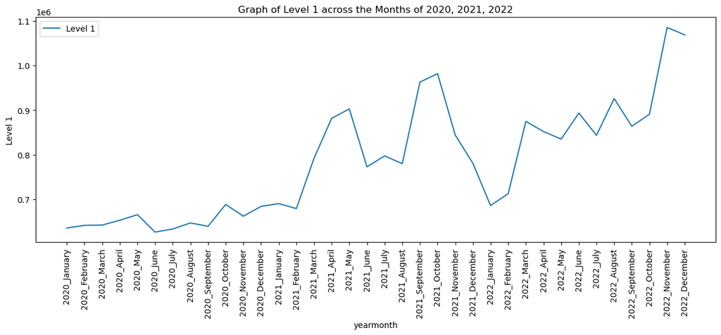

```python
plt.figure(figsize = (15, 5))
sns.lineplot(data = df10.sort_values(by = ['Year','month1'],ascending = True),x='yearmonth', y='Level 1',ci=None).set(title =
                                        'Graph of Level 1 across the Months of 2020, 2021, 2022')

plt.legend(labels=["Level 1"])
plt.xticks(rotation =  90 )
plt.show()
```

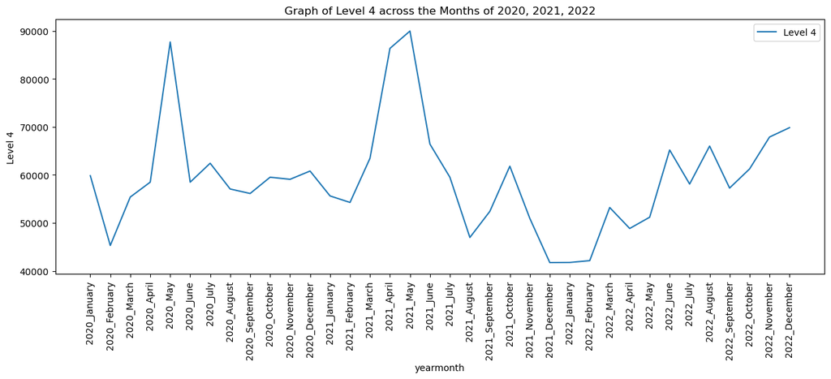

```python
plt.figure(figsize = (15, 5))
sns.lineplot(data = df10.sort_values(by = ['Year','month1'],ascending = True),x='yearmonth', y='Level 4',ci=None).set(title =
                                                            'Graph of Level 4 across the Months of 2020, 2021, 2022')
plt.legend(labels=['Level 4'])
plt.xticks(rotation =  90 )
plt.show()
```

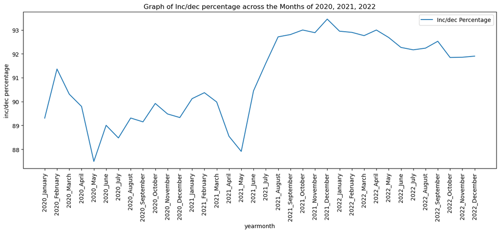

```python
plt.figure(figsize = (15, 5))
sns.lineplot(data = df10.sort_values(by = ['Year','month1'],ascending = True),x='yearmonth', y='inc/dec percentage',ci=None).set(title =
                                                    'Graph of Inc/dec percentage across the Months of 2020, 2021, 2022')
plt.legend(labels=['Inc/dec Percentage'])
plt.xticks(rotation =  90 )
plt.show()
```

#### 5 A line graph for “Level 3” and “Place_in_India” over the months of the year 2020 and 2021

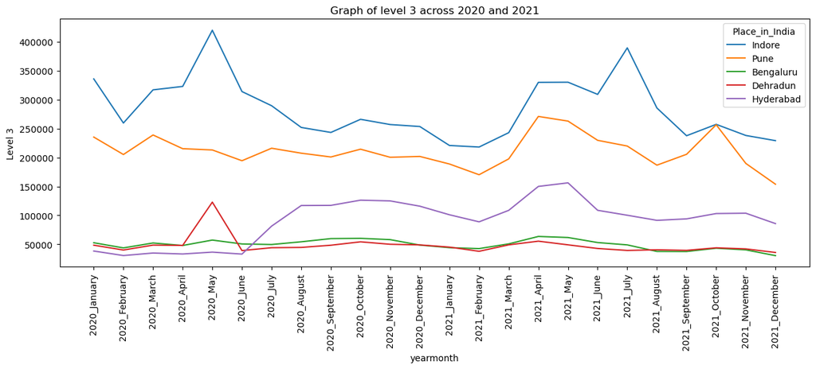

```python
plt.figure(figsize=(15, 5))
sns.lineplot(data = df10.loc[(df['Year'] == 2020) | (df['Year'] == 2021)].sort_values(by = ['Year','month1'],ascending = True),
        x = 'yearmonth', y = 'Level 3', ci = None, hue = 'Place_in_India').set(title = 'Graph of level 3 across 2020 and 2021')
plt.xticks(rotation = 90)
plt.show()
```

#### 6 A well visualized bar graph showing the “Level 1” from various places in India, also, representing the type of customers, for the year 2022

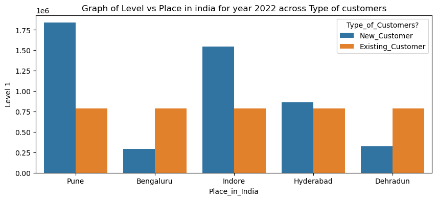

```python
plt.figure(figsize = (10,4))
sns.barplot(data = df10.loc[(df['Year'] == 2022)], x = 'Place_in_India' , y= 'Level 1', hue = 'Type_of_Customers?',
           ci = None).set(title = 'Graph of Level vs Place in india for year 2022 across Type of customers')
plt.show()
```

#### 7 Please add any insights you could derive from all the graphs above

1. The trend for Dehradun and Bengaluru is same across the months of 2020 and 2021
2. We can observe that the traffic from desktop_website less than laptop_website for the year 2020.
3. In the year 2021 Desktop_website traffic is more than laptop_website traffic.
4. The traffic from Direct_traffic is more and is following increasing trend compared to sources From linkedin and Unidentified_sources
5. The trend of level 3 for Indore and Pune is greater than other locations
6. The new customers for year 2022 have increased for location Pune, Indore and Hyderabad but decreased for Bengaluru and Dehradun location

### Part 6: About the Previous projects

● Please describe any interesting project you did in the Data Science domain in more than 250 words. Attach Github links if possible.

During my internship at Innomatics Research Labs one of the projects that excited me was application development on streamlit of Diamond Price prediction machine learning model. This project objective was to predict the price of the Diamond given the input parameter like cut, depth, height etc. And to develop a web based application using Streamlit. The classic Diamonds dataset contains the prices and other attributes of almost 54,000 diamonds. The dataset contains 53940 rows and 10 variables. The methodology of the project is as follow

1. Perform the Exploratory data analysis. The EDA mainly focused on the cleaning the dataset, checking for null values, outlier detection and applying visualization tools to understand the relationships and distributions of the data.
2. Under visualization the box plot was used to detect the outliers present in the data. The pair plot was used to visualize the relationship and trend that was hidden in the data. The Heat map was used to study the correlation between the independent variable and dependent variable to understand the impact of each independent variable on the dependent variable.
3. Feature engineering: The categorical variables were encoded before the model development.
4. Model Development: Few different Regression models were implemented to study the performances and to select the optimum performing model.
5. Pickling: The optimum performing model was converted into pickle file using the Serialization technique for the application development.
6. Application Development – Streamlit: The trained pickled model was un-pickled and used in the application development. The input data from user was converted into suitable form in order to perform the prediction.
7. Github link = https://github.com/rohith7799/Diamond-Price-Prediction-Streamlit-App

### Part 7: Time management

● Can you please share your thoughts, in less than 120 words, on “If you get selected, how will you manage your time for this full-time internship opportunity”

1. Prioritize tasks by importance and urgency.
2. Devote the considerable amount of time on the task that is in hand.
3. Communicating with fellow interns/colleagues for help.
4. Try to learn new concepts regarding the task with the help of mentors and friends.
5. Ask Mentors/Manager for help whenever there is a need of it.
6. Start day early with clear goal and target that needs to be done.
7. Talking to Mentors/Manager in the beginning to get their feedback on priorities and how long they feel tasks should take.